# Compito (con soluzioni)

Scrivere in stampatello

| COGNOME | $\LARGE\square$ | $\LARGE\square$ | $\LARGE\square$ | $\LARGE\square$ | $\LARGE\square$ | $\LARGE\square$ | $\LARGE\square$ | $\LARGE\square$ | $\LARGE\square$ | $\LARGE\square$ | $\LARGE\square$ | $\LARGE\square$ | $\LARGE\square$ | $\LARGE\square$ | $\LARGE\square$ | $\LARGE\square$ | $\LARGE\square$ | $\LARGE\square$ | $\LARGE\square$ | $\LARGE\square$ |
| --- | --- | --- | --- | --- | --- | --- | --- | --- | --- | --- | --- | --- | --- | --- | --- | --- | --- | --- | --- | --- |
| NOME | $\LARGE\square$ | $\LARGE\square$ | $\LARGE\square$ | $\LARGE\square$ | $\LARGE\square$ | $\LARGE\square$ | $\LARGE\square$ | $\LARGE\square$ | $\LARGE\square$ | $\LARGE\square$ | $\LARGE\square$ | $\LARGE\square$ | $\LARGE\square$ | $\LARGE\square$ | $\LARGE\square$ | $\LARGE\square$ | $\LARGE\square$ | $\LARGE\square$ | $\LARGE\square$ | $\LARGE\square$ |
| Matricola | $\LARGE\square$ | $\LARGE\square$ | $\LARGE\square$ | $\LARGE\square$ | $\LARGE\square$ | $\LARGE\square$ | $\LARGE\square$ | $\LARGE\square$ | $\LARGE\square$ | $\LARGE\square$ | $\LARGE\square$ | $\LARGE\square$ | $\LARGE\square$ | $\LARGE\square$ | $\LARGE\square$ | $\LARGE\square$ | $\LARGE\square$ | $\LARGE\square$ | $\LARGE\square$ | $\LARGE\square$ |
| CDL | $\LARGE\square$ | $\LARGE\square$ | $\LARGE\square$ | $\LARGE\square$ | $\LARGE\square$ |  |  |  |  |  |  |  |  |  |  |  |  |  |  |  |

### Esercizio 1

Su un campione di $250$ famiglie della provincia di Ferrara è stato rilevata la spesa in generi alimentari (espresso in migliaia di euro). Qui di seguito i dati raccolti in classe e le densità di frequenza percentuali

| $[\text{x}_j,$ | $\text{x}_{j+1})$ | $h_j$ |
| --- | --- | --- |
| 0 | 3 | 2.40 |
| 3 | 5 | 19.60 |
| 5 | 10 | 7.12 |
| 10 | 20 | 1.80 |

1.a (**Punti 14 su 104 (4.04 su 30)**) Calcolare il valore approssimato della mediana.

| $[\text{x}_j,$ | $\text{x}_{j+1})$ | $f_{j\%}$ | $n_j$ | $f_j$ | $b_j$ | $h_j$ | $F_j$ |
| --- | --- | --- | --- | --- | --- | --- | --- |
| 0 | 3 | 7.2 | 18 | 0.072 | 3 | 2.40 | 0.072 |
| 3 | 5 | 39.2 | 98 | 0.392 | 2 | 19.60 | 0.464 |
| 5 | 10 | 35.6 | 89 | 0.356 | 5 | 7.12 | 0.820 |
| 10 | 20 | 18.0 | 45 | 0.180 | 10 | 1.80 | 1.000 |
|  |  | 100.0 | 250 | 1.000 | 20 |  |  |

$$\begin{eqnarray*}
p &=& 0.5, \text{essendo }F_{3}=0.82 >0.5 \Rightarrow
j_{0.5}=3\\
x_{0.5} &=& x_{\text{inf};3} + \frac{ {0.5} - F_{2}} {f_{3}}
\cdot b_{3} \\
&=& 5 + \frac {{0.5} - 0.464} {0.356} \cdot 5 \\
&=& 5.5056
\end{eqnarray*}$$

1.b (**Punti 3 su 104 (0.87 su 30)**) Quante famiglie hanno una spesa inferiore al 25-esimo percentile?

$$250\times 0.25=62.5$$

1.c (**Punti 2 su 104 (0.58 su 30)**) La spesa media è pari a $\bar x=6.9973$, che forma ci dobbiamo aspettare dell’istogramma di densità?

1.d (**Punti 2 su 104 (0.58 su 30)**) La varianza della spesa è pari a $Var=18.3466$. Se ogni famiglia aumentasse la sua spesa del 5%, quanto varrebbe varianza dei dati così trasformati?

$$20.2272$$

### Esercizio 2

- $A=$ “l’estrazione dall’urna A dà al massimo una pallina rossa (1 pallina rossa o meno)”.
- $B=$ “L’estrazione dall’urna B dà come risultato almeno 4 palline blu (4 o più palline blu)”.

2.a **(Punti 14 su 104 (4.04 su 30))** Calcola la probabilità che almeno uno dei due eventi sia vero, ovvero la probabilità di $A \cup B$.

$$\begin{eqnarray*}
P( X \leq 1 ) &=& \binom{ 5 }{ 0 } 0.3333 ^{ 0 }(1- 0.3333 )^{
5 - 0 }+\binom{ 5 }{ 1 } 0.3333 ^{ 1 }(1- 0.3333 )^{ 5 - 1 }
\\ &=& 0.1317+0.3293
\\ &=& 0.461
\end{eqnarray*}$$

$$\begin{eqnarray*}
P( Y \geq 4 ) &=& \binom{ 5 }{ 4 } 0.6667 ^{ 4 }(1- 0.6667 )^{
5 - 4 }+\binom{ 5 }{ 5 } 0.6667 ^{ 5 }(1- 0.6667 )^{ 5 - 5 }
\\ &=& 0.3293+0.1317
\\ &=& 0.461
\end{eqnarray*}$$

$$\begin{eqnarray*}
P(A\cup B) &=& P(A)+P(B)-P(A\cap B)\\
&=& 0.4609+0.4609-0.2124\\
&=& 0.7094
\end{eqnarray*}$$

2.b (**Punti 3 su 104 (0.87 su 30)**) Qual è la probabilità di avere **esattamente** uno solo due eventi sia vera?

$$\begin{eqnarray*}
P(A) &=& 0.4609\\
P(B) &=& 0.4609\\
P(\text{Solo uno dei due vero}) &=& P(A\cap\bar B)+P(\bar
A\cap B)\\
&=& 0.4609\times (1 - 0.4609)+(1-0.4609)\times 0.4609\\
&=& 0.4969
\end{eqnarray*}$$

2.c (**Punti 2 su 104 (0.58 su 30)**) Siano $X_1\sim N(5,1)$ e $X_2\sim N(5,1)$, $X_1$ e $X_2$ indipendenti. Come si distribuisce
$$\bar X = \frac 12 (X_1+X_2) ~~~?$$

2.d (**Punti 2 su 104 (0.58 su 30)**) Siano $A$ e $B$ due eventi tali che $P(A)=0.3$ e $P(B)=0.3$. $A$ e $B$ possono essere incompatibili? (scegliere tra *sempre, mai, dipende* e motivare la risposta)

### Esercizio 3

(**Punti 14 su 104 (4.04 su 30)**) Un’urna contiene $4$ bussolotti Rossi, $3$ bussolotti Blu e $5$ bussolotti Gialli. Si estrae 60 volte con reintroduzione; qual è la probabilità che il numero di rossi in 60 estrazioni sia maggiore di 21?

$$\pi=\frac 4{12}=\frac 13$$
**Teorema del Limite Centrale (somma di Bernoulli)**

Siano $X_1$,…,$X_n$, $n=60$ VC IID, tc $X_i\sim\text{Ber}(\pi=0.3333)$$,\forall i$, posto:
$$S_n = X_1 + ... + X_n$$
allora:
$$\begin{eqnarray*}
S_n & \mathop{\sim}\limits_{a}& N(n\pi,n\pi(1-\pi)) \\
&\sim & N(60\cdot0.3333,60\cdot0.3333\cdot(1-0.3333)) \\
&\sim & N(20,13.33)
\end{eqnarray*}$$

$$\begin{eqnarray*}
P(S_n > 21)
&=& P\left( \frac {S_n - n\pi}{\sqrt{n\pi(1-\pi)}} > \frac
{21 - 20}{\sqrt{13.3333}} \right) \\
&=& P\left( Z > 0.27\right) \\ &=&
1-P(Z< 0.27 )\\
&=& 1-\Phi( 0.27 ) \\ &=& 0.3936
\end{eqnarray*}$$

### Esercizio 4

4.a (**Punti 3 su 104 (0.87 su 30)**) Sia $\hat \lambda$ lo stimatore di massima verosimiglianza di $\lambda$ del modello di Poisson.
$$\begin{eqnarray*}
\hat\lambda &=& \frac 1n\sum_{i=1}^nx_i\\
\end{eqnarray*}$$
Dimostrare le correttezza di $\hat\lambda$ in almeno tre passaggi.

4.b (**Punti 2 su 104 (0.58 su 30)**) Definire lo *Standard Error* di uno stimatore.

4.c (**Punti 3 su 104 (0.87 su 30)**) Definire gli errori di primo e di secondo tipo di un test statistico.

4.d (**Punti 3 su 104 (0.87 su 30)**) In un test statistico, per quali valori di $p_\text{value}$ si tende a rifiutare $H_0$?

### Esercizio 5

5.a (**Punti 7 su 104 (2.02 su 30)**) In uno studio sui redditi, nel comune $A$ si è rilevato il reddito di $n=35$ individui e si è osservata una media pari $68$ mila euro con una standard deviation pari a $5$ mila euro. Costruire un intervallo di confidenza al 95% per il reddito medio $\mu$.

5.b (**Punti 7 su 104 (2.02 su 30)**) Un’indagine analoga, svolta sull’intera regione, ha mostrato un reddito medio pari a $\mu_0=71$. Testare al livello di **significatività del 5%** l’ipotesi che nel comune $A$ il reddito medio sia uguale a quello regionale contro l’alternativa che sia **diverso**.

$\fbox{A}$ FORMULAZIONE DELLE IPOTESI
$$\begin{cases}
H_0:\mu=\mu_0=71\text{}\\
H_1:\mu\neq \mu_0=71\text{}
\end{cases}$$
Siccome $H_1$ è bilaterale, considereremo $\alpha/2$, anziché $\alpha$

$\fbox{B}$ SCELTA E CALCOLO STATISTICA-TEST, $T$ $\sigma^{2}$ di $\cal{P}$ non è nota: $\Rightarrow$ t-Test.
$$\begin{eqnarray*}
S
&=& \sqrt{\frac{n} {n-1}}\ \widehat{\sigma}
= \sqrt{\frac{35} {35-1}} \times 5 = 5.073
\end{eqnarray*}$$

$$\begin{eqnarray*}
\frac{\hat\mu - \mu_{0}} {S/\,\sqrt{n}}&\sim&t_{n-1}\\
t_{\text{obs}}
&=& \frac{ (68- 71)} {5.073/\sqrt{35}}
= -3.4986\, .
\end{eqnarray*}$$

$\fbox{C}$ DECISIONE Dalle tavole si ha $t_{(35-1);\, 0.025} = -2.0322$.
$$t_{\text{obs}} = -3.4986
< t_{34;\, 0.025} = -2.0322$$
CONCLUSIONE: i dati **non** sono coerenti con $H_{0}$ al LdS del 5%

**Graficamente**

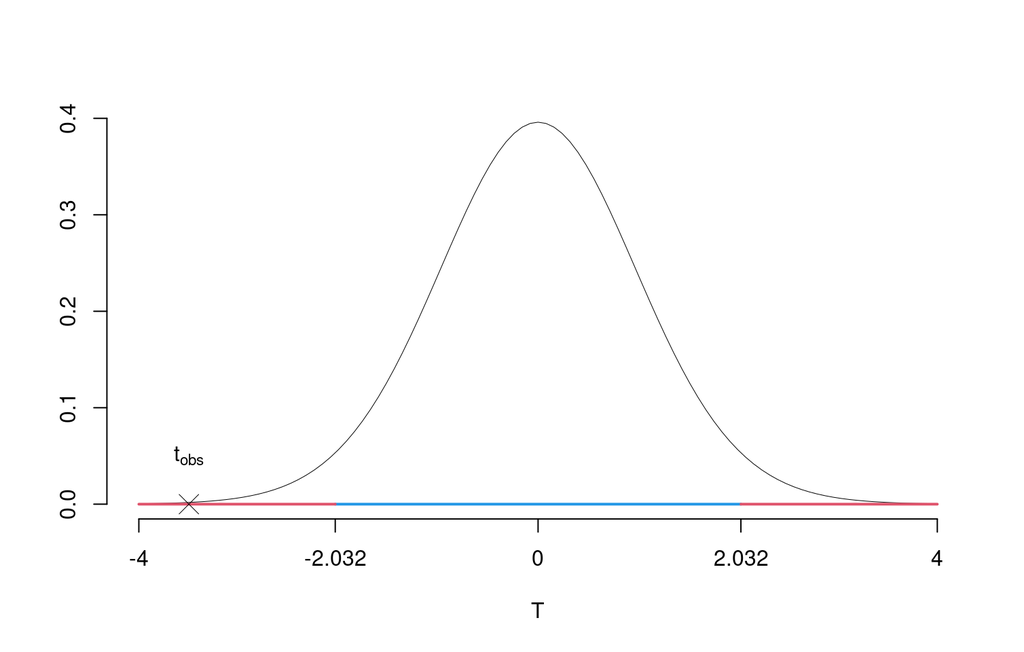

Il $p_{\text{value}}$ è
$$P(|T_{n-1}|>|t_{\text{obs}}|)=2P(T_{n-1}>|t_{\text{obs}}|)=2P(T_{n-1}>|
-3.4986 |)= 0.001326$$

### Esercizio 6

In uno studio sull’efficacia del marketing sul web si sono analizzate 4 aziende sulle quali è stato misurata l’incremento percentuale annuo medio di investimento in marketing web ($X$) la l’incremento percentuale in altre campagne di marketing ($Y$).

Qui di seguito i dati

| $i$ | $x_i$ | $y_i$ |
| --- | --- | --- |
| 1 | 0.34 | 1.48 |
| 2 | 0.37 | 0.79 |
| 3 | 0.68 | 0.82 |
| 4 | 1.02 | 0.00 |
| Totale | 2.41 | 3.09 |

6.a (**Punti 14 su 104 (4.04 su 30)**) Stimare il modello di regressione dove $Y$ viene spiegata da $X$ e interpretare e calcolare il residuo per $x=0.37$.

| $i$ | $x_i$ | $y_i$ | $x_i^2$ | $y_i^2$ | $x_i\cdot y_i$ |
| --- | --- | --- | --- | --- | --- |
| 1 | 0.3400 | 1.4800 | 0.12 | 2.19 | 0.5000 |
| 2 | 0.3700 | 0.7900 | 0.14 | 0.62 | 0.2900 |
| 3 | 0.6800 | 0.8200 | 0.46 | 0.67 | 0.5600 |
| 4 | 1.0200 | 0.0000 | 1.04 | 0.00 | 0.0000 |
| Totale | 2.4100 | 3.0900 | 1.76 | 3.48 | 1.3500 |
| Totale/n | 0.6025 | 0.7725 | 0.44 | 0.87 | 0.3375 |

$$\begin{eqnarray*}
\bar x &=&\frac 1 n\sum_{i=1}^n x_i = \frac {1}{4} 2.41=
0.6025\\
\bar y &=&\frac 1 n\sum_{i=1}^n y_i = \frac {1}{4} 3.09=
0.7725\\
\hat\sigma_X^2&=&\frac 1 n\sum_{i=1}^n x_i^2-\bar x^2=\frac
{1}{4} 1.7553 -0.6025^2=0.0758\\
\hat\sigma_Y^2&=&\frac 1 n\sum_{i=1}^n y_i^2-\bar y^2=\frac
{1}{4} 3.4869 -0.7725^2=0.275\\
\text{cov}(X,Y)&=&\frac 1 n\sum_{i=1}^n x_i~y_i-\bar x\bar
y=\frac {1}{4} 1.3531-0.6025\cdot0.7725=-0.1272\\
\hat\beta_1 &=& \frac{\text{cov}(X,Y)}{\hat\sigma_X^2} \\
&=& \frac{-0.1272}{0.0758} = -1.6771\\
\hat\beta_0 &=& \bar y - \hat\beta_1 \bar x\\
&=& 0.7725-(-1.6771)\times 0.6025=1.783
\end{eqnarray*}$$

$$\begin{eqnarray*}
\hat y_i &=&\hat\beta_0+\hat\beta_1 x_i=\\
&=& 1.783 + (-1.6771) \times 0.37 = 1.162 \\
\hat \varepsilon_i &=& y_i-\hat y_i\\
&=& 0.79 - 1.162 = -0.3724
\end{eqnarray*}$$

6.b (**Punti 3 su 104 (0.87 su 30)**) Il modello si adatta bene ai dati?

$$\begin{eqnarray*}
r&=&\frac{\text{cov}(X,Y)}{\sigma_X\sigma_Y}=\frac{ -0.1272 }{
0.2754 \times 0.5244 }= -0.8807 \\r^2&=& 0.7756 > 0.75
\end{eqnarray*}$$
Il modello si adatta bene ai dati.

6.c (**Punti 2 su 104 (0.58 su 30)**) Che differenza c’è tra interpolazione ed estrapolazione?

6.d (**Punti 2 su 104 (0.58 su 30)**) Definire il diagramma dei residui.

6.e (**Punti 2 su 104 (0.58 su 30)**) Cosa significa che $\hat\beta_0$ e $\hat\beta_1$ sono BLUE?